# Hypothesis testing intro

```r
library(infer)
library(janitor)
library(tidyverse)
```

# One sample mean

```r
books <- read_csv("1_one_sample_tests_mean/data/books.csv")
```

[output not shown]

```r
glimpse(books)
```

```
Rows: 11,004
Columns: 10
$ bookID             <dbl> 1, 2, 3, 4, 5, 8, 9, 10, 12, 13, 14, 16, 18, 21, 22, 23, 24, 2…
$ title              <chr> "Harry Potter and the Half-Blood Prince (Harry Potter  #6)", "…
$ authors            <chr> "J.K. Rowling-Mary GrandPré", "J.K. Rowling-Mary GrandPré", "J…
$ average_rating     <dbl> 4.56, 4.49, 4.47, 4.41, 4.55, 4.78, 3.69, 4.73, 4.38, 4.38, 4.…
$ isbn               <chr> "0439785960", "0439358078", "0439554934", "0439554896", "04396…
$ isbn13             <chr> "9780439785969", "9780439358071", "9780439554930", "9780439554…
$ language_code      <chr> "eng", "eng", "eng", "eng", "eng", "eng", "en-US", "eng", "eng…
$ `# num_pages`      <dbl> 652, 870, 320, 352, 435, 2690, 152, 3342, 815, 815, 215, 6, 81…
$ ratings_count      <dbl> 1944099, 1996446, 5629932, 6267, 2149872, 38872, 18, 27410, 36…
$ text_reviews_count <dbl> 26249, 27613, 70390, 272, 33964, 154, 1, 820, 258, 3954, 408, …
```

```r
books_tidy <- books %>%
  clean_names() %>%
  filter(!is.na(average_rating)) %>%
  rename(num_pages = number_num_pages)
glimpse(books_tidy)
```

```
Rows: 10,999
Columns: 10
$ book_id            <dbl> 1, 2, 3, 4, 5, 8, 9, 10, 12, 13, 14, 16, 18, 21, 22, 23, 24, 2…
$ title              <chr> "Harry Potter and the Half-Blood Prince (Harry Potter  #6)", "…
$ authors            <chr> "J.K. Rowling-Mary GrandPré", "J.K. Rowling-Mary GrandPré", "J…
$ average_rating     <dbl> 4.56, 4.49, 4.47, 4.41, 4.55, 4.78, 3.69, 4.73, 4.38, 4.38, 4.…
$ isbn               <chr> "0439785960", "0439358078", "0439554934", "0439554896", "04396…
$ isbn13             <chr> "9780439785969", "9780439358071", "9780439554930", "9780439554…
$ language_code      <chr> "eng", "eng", "eng", "eng", "eng", "eng", "en-US", "eng", "eng…
$ num_pages          <dbl> 652, 870, 320, 352, 435, 2690, 152, 3342, 815, 815, 215, 6, 81…
$ ratings_count      <dbl> 1944099, 1996446, 5629932, 6267, 2149872, 38872, 18, 27410, 36…
$ text_reviews_count <dbl> 26249, 27613, 70390, 272, 33964, 154, 1, 820, 258, 3954, 408, …
```

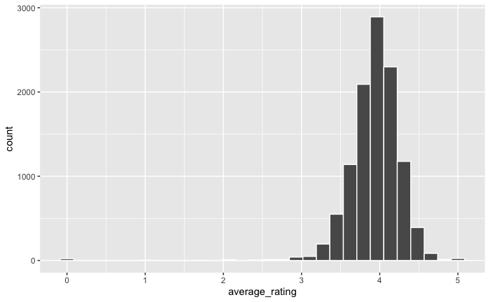

```r
books_tidy %>%
  ggplot(aes(x = average_rating)) +
  geom_histogram(col = "white", bins = 30)
```

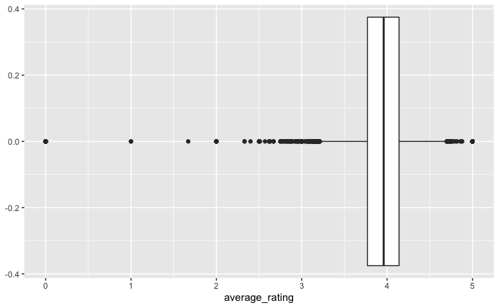

```r
books_tidy %>%
  ggplot(aes(x = average_rating)) +
  geom_boxplot()
```

How does the mean of this sample (sample (not full) of 2020) compare to another year.

```r
observed_stat <- books_tidy %>%
  summarise(mean_rating = mean(average_rating))
observed_stat
```

| mean_rating |
| --- |
| 3.937568 |

#### Calculating null hypothesis distribution:

```r
null_distribution <- books_tidy %>%
  specify(response = average_rating) %>%
  hypothesise(null = "point", mu = 3.93) %>%
  generate(reps = 10000, type = "bootstrap") %>%
  calculate(stat = "mean")
null_distribution
```

| replicate | stat |
| --- | --- |
| 1 | 3.934519 |
| 2 | 3.930065 |
| 3 | 3.931422 |
| 4 | 3.928493 |
| 5 | 3.936401 |
| 6 | 3.930329 |
| 7 | 3.928639 |
| 8 | 3.927208 |
| 9 | 3.926612 |
| 10 | 3.932289 |

[output cut: 990 more lines]

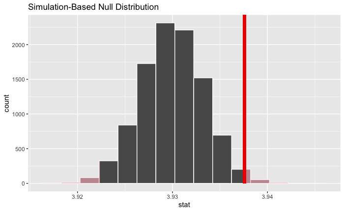

```r
null_distribution %>%
  visualise() +
  shade_p_value(obs_stat = observed_stat$mean_rating, direction = "both")
```

```r
p_value <- null_distribution %>%
  get_p_value(obs_stat = observed_stat$mean_rating, direction = "both")
p_value
```

| p_value |
| --- |
| 0.0208 |

# TASK

```r
spa_books <- books_tidy %>%
  filter(language_code == "spa")
spa_books
```

| book_id | title | authors | average_rating | isbn | isbn13 | language_code | num_pages | ratings_count | text_reviews_count |
| --- | --- | --- | --- | --- | --- | --- | --- | --- | --- |
| 201 | Una arruga en el tiempo – A Wrinkle in Time | Madeleine L'Engle | 4.01 | 0606105263 | 9780606105262 | spa | 205 | 6 | 1 |
| 324 | Cien años de soledad | Gabriel García Márquez | 4.06 | 0785950109 | 9780785950103 | spa | 448 | 54 | 6 |
| 325 | Cien años de soledad | Gabriel García Márquez | 4.06 | 8423919005 | 9788423919000 | spa | 456 | 73 | 8 |
| 337 | El perfume: Historia de un asesino | Patrick Süskind | 4.02 | 8432216062 | 9788432216060 | spa | 239 | 3956 | 242 |
| 762 | Crónica de una muerte anunciada | Gabriel García Márquez | 3.96 | 1400034957 | 9781400034956 | spa | 118 | 7210 | 371 |
| 763 | Cien años de soledad | Gabriel García Márquez | 4.06 | 0307350428 | 9780307350428 | spa | 496 | 128 | 6 |
| 764 | Del amor y otros demonios | Gabriel García Márquez | 3.98 | 0307350444 | 9780307350442 | spa | 176 | 3958 | 237 |
| 766 | Memoria de mis putas tristes | Gabriel García Márquez | 3.59 | 1400095808 | 9781400095803 | spa | 112 | 5065 | 312 |
| 797 | Lonely Planet Londres | Lonely Planet-Sarah Johnstone-Tom Masters | 4.03 | 8408064762 | 9788408064763 | spa | 480 | 0 | 0 |
| 965 | Ángeles y demonios (Robert Langdon #1) | Dan Brown | 3.88 | 849561877X | 9788495618771 | spa | 508 | 197 | 22 |

[output cut: 268 more lines]

```r
spa_books_obs_stat <- spa_books %>%
  summarise(mean_rating = mean(average_rating))
spa_books_obs_stat
```

| mean_rating |
| --- |
| 3.943381 |

```r
spa_books_null_distribution <- spa_books %>%
  specify(response = average_rating) %>%
  hypothesise(null = "point", mu = 3.96) %>%
  generate(reps = 10000, type = "bootstrap") %>%
  calculate(stat = "mean")
spa_books_null_distribution
```

| replicate | stat |
| --- | --- |
| 1 | 3.956942 |
| 2 | 3.959496 |
| 3 | 3.956259 |
| 4 | 3.961835 |
| 5 | 3.948273 |
| 6 | 3.943921 |
| 7 | 3.962878 |
| 8 | 3.952482 |
| 9 | 3.979353 |
| 10 | 3.926835 |

[output cut: 990 more lines]

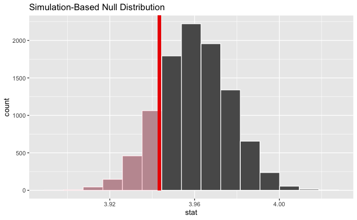

```r
spa_books_null_distribution %>%
  visualise() +
  shade_p_value(obs_stat = spa_books_obs_stat$mean_rating, direction = "left")
```

```r
p_value <- spa_books_null_distribution %>%
  get_p_value(obs_stat = spa_books_obs_stat$mean_rating, direction = "left")
p_value
```

| p_value |
| --- |
| 0.1573 |

# One sample proportions.

Proportion of books without text reviews.

```r
books_tidy %>%
  group_by(text_reviews_count) %>%
  summarise(prop = n()/nrow(books_tidy)) %>%
  filter(text_reviews_count == 0)
```

| text_reviews_count | prop |
| --- | --- |
| 0 | 0.06455132 |

```r
books_tidy_prop <- books_tidy %>%
  mutate(text_reviews_flag = ifelse(text_reviews_count > 0, "text_review", "no_text_review"))

head(books_tidy_prop)
```

| book_id | title | authors | average_rating | isbn | isbn13 | language_code | num_pages | ratings_count | text_reviews_count | text_reviews_flag |
| --- | --- | --- | --- | --- | --- | --- | --- | --- | --- | --- |
| 1 | Harry Potter and the Half-Blood Prince (Harry Potter #6) | J.K. Rowling-Mary GrandPré | 4.56 | 0439785960 | 9780439785969 | eng | 652 | 1944099 | 26249 | text_review |
| 2 | Harry Potter and the Order of the Phoenix (Harry Potter #5) | J.K. Rowling-Mary GrandPré | 4.49 | 0439358078 | 9780439358071 | eng | 870 | 1996446 | 27613 | text_review |
| 3 | Harry Potter and the Sorcerer's Stone (Harry Potter #1) | J.K. Rowling-Mary GrandPré | 4.47 | 0439554934 | 9780439554930 | eng | 320 | 5629932 | 70390 | text_review |
| 4 | Harry Potter and the Chamber of Secrets (Harry Potter #2) | J.K. Rowling | 4.41 | 0439554896 | 9780439554893 | eng | 352 | 6267 | 272 | text_review |
| 5 | Harry Potter and the Prisoner of Azkaban (Harry Potter #3) | J.K. Rowling-Mary GrandPré | 4.55 | 043965548X | 9780439655484 | eng | 435 | 2149872 | 33964 | text_review |
| 8 | Harry Potter Boxed Set Books 1-5 (Harry Potter #1-5) | J.K. Rowling-Mary GrandPré | 4.78 | 0439682584 | 9780439682589 | eng | 2690 | 38872 | 154 | text_review |

Because we need a proportion, we cannot do bootstrapping, but need simulation.

```r
null_distribution <- books_tidy_prop %>%
  specify(response = text_reviews_flag, success = "no_text_review") %>%
  hypothesise(null = "point", p = 0.07) %>%
  generate(reps = 5000, type = "simulate") %>%
  calculate(stat = "prop")
head(null_distribution)
```

| replicate | stat |
| --- | --- |
| 1 | 0.07264297 |
| 2 | 0.06973361 |
| 3 | 0.07046095 |
| 4 | 0.06909719 |
| 5 | 0.07182471 |
| 6 | 0.07146104 |

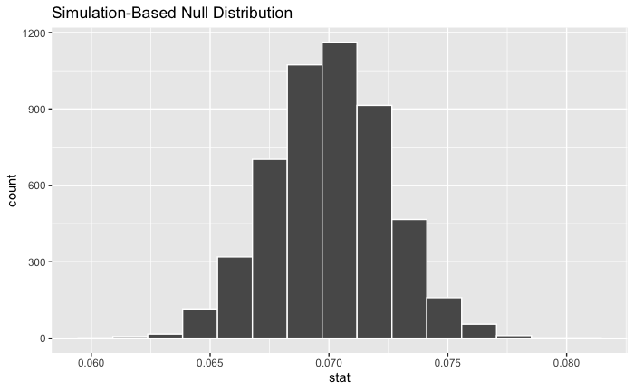

```r
null_distribution %>%
  visualise()
```

```r
observed_stat <- books_tidy_prop %>%
  specify(response = text_reviews_flag, success = "no_text_review") %>%
  calculate(stat = "prop")
observed_stat
```

| stat |
| --- |
| 0.06455132 |

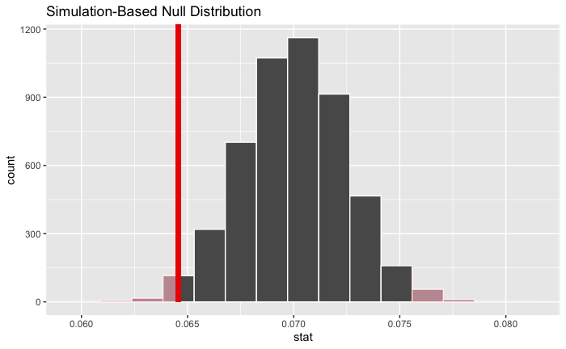

```r
null_distribution %>%
  visualise() +
  shade_p_value(obs_stat = observed_stat, direction = "both")
```

```r
null_distribution %>%
  get_p_value(obs_stat = observed_stat, direction = "both")
```

| p_value |
| --- |
| 0.0272 |

H0 = 0.015 Ha < 0.015 sig level is 1%

```r
#unique(books_tidy$language_code)
books_tidy %>%
  group_by(language_code) %>%
  summarise(prop = n()/nrow(books_tidy)) %>%
  filter(language_code == "fre")
```

| language_code | prop |
| --- | --- |
| fre | 0.01472861 |

```r
books_tidy_prop_fre <- books_tidy %>%
  mutate(language_flag = ifelse(language_code == "fre", "fre_language", "other_language"))
head(books_tidy_prop_fre)
```

| book_id | title | authors | average_rating | isbn | isbn13 | language_code | num_pages | ratings_count | text_reviews_count | language_flag |
| --- | --- | --- | --- | --- | --- | --- | --- | --- | --- | --- |
| 1 | Harry Potter and the Half-Blood Prince (Harry Potter #6) | J.K. Rowling-Mary GrandPré | 4.56 | 0439785960 | 9780439785969 | eng | 652 | 1944099 | 26249 | other_language |
| 2 | Harry Potter and the Order of the Phoenix (Harry Potter #5) | J.K. Rowling-Mary GrandPré | 4.49 | 0439358078 | 9780439358071 | eng | 870 | 1996446 | 27613 | other_language |
| 3 | Harry Potter and the Sorcerer's Stone (Harry Potter #1) | J.K. Rowling-Mary GrandPré | 4.47 | 0439554934 | 9780439554930 | eng | 320 | 5629932 | 70390 | other_language |
| 4 | Harry Potter and the Chamber of Secrets (Harry Potter #2) | J.K. Rowling | 4.41 | 0439554896 | 9780439554893 | eng | 352 | 6267 | 272 | other_language |
| 5 | Harry Potter and the Prisoner of Azkaban (Harry Potter #3) | J.K. Rowling-Mary GrandPré | 4.55 | 043965548X | 9780439655484 | eng | 435 | 2149872 | 33964 | other_language |
| 8 | Harry Potter Boxed Set Books 1-5 (Harry Potter #1-5) | J.K. Rowling-Mary GrandPré | 4.78 | 0439682584 | 9780439682589 | eng | 2690 | 38872 | 154 | other_language |

```r
fre_null_distribution <- books_tidy_prop_fre %>%
  specify(response = language_flag, success = "fre_language") %>%
  hypothesise(null = "point", p = 0.015) %>%
  generate(reps = 2000, type = "simulate") %>%
  calculate(stat = "prop")

head(fre_null_distribution)
```

| replicate | stat |
| --- | --- |
| 1 | 0.01391036 |
| 2 | 0.01472861 |
| 3 | 0.01400127 |
| 4 | 0.01491045 |
| 5 | 0.01563779 |
| 6 | 0.01491045 |

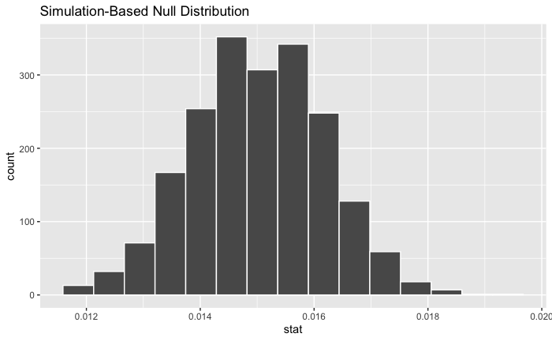

```r
fre_null_distribution %>%
  visualise()
```

```r
fre_observed_stat <- books_tidy_prop_fre %>%
  specify(response = language_flag, success = "fre_language") %>%
  calculate(stat = "prop")
fre_observed_stat
```

| stat |
| --- |
| 0.01472861 |

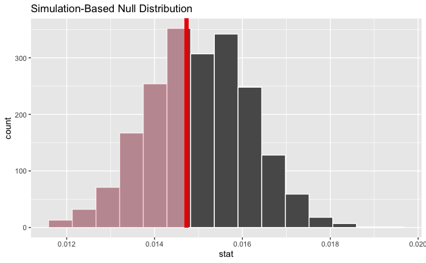

```r
fre_null_distribution %>%
  visualise() +
  shade_p_value(obs_stat = fre_observed_stat, direction = "less")
```

```r
fre_null_distribution %>%
get_p_value(obs_stat = fre_observed_stat, direction = "less")
```

| p_value |
| --- |
| 0.4125 |

# Two sample tests

## Independent samples.

We have two samples of prices (in £s) for 2-bedroom, 14-day holiday apartment lets in Nice and the Algarve. We would like to know whether the mean price of lets in the Algarve is significantly higher than the mean price of comparable lets in Nice?’ alpha = 0.05 H0: mu_algarve - mu_nice = 0 Ha: mu_algarve - mu_nice > 0

```r
nice <- read_csv("3_two_sample_tests/data/nice.csv")
algarve <- read_csv("3_two_sample_tests/data/algarve.csv")
```

```r
apart_prices <- bind_rows(nice, algarve, .id = "location") %>%
  mutate(location = ifelse(location == "1", "nice", "algarve")) %>%
  select(-X1)
  apart_prices
```

| location | price |
| --- | --- |
| nice | 1594 |
| nice | 1537 |
| nice | 1565 |
| nice | 1477 |
| nice | 2072 |
| nice | 1608 |
| nice | 1482 |
| nice | 2249 |
| nice | 2238 |
| nice | 1761 |

[output cut: 90 more lines]

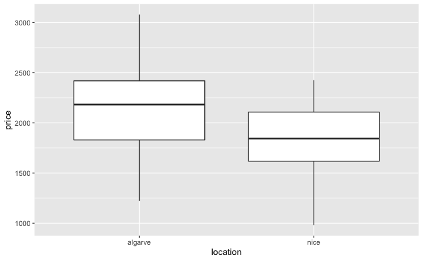

```r
apart_prices %>%
  ggplot(aes(x = location, y = price)) +
  geom_boxplot()
```

Null by permutation

```r
null_distribution <- apart_prices %>%
  specify(response = price, explanatory = location) %>% #(price ~ location)
  hypothesise(null = "independence") %>%
  generate(reps = 5000, type = "permute") %>%
  calculate(stat = "diff in means", order = c("algarve", "nice"))
null_distribution
```

| replicate | stat |
| --- | --- |
| 1 | 52.1916667 |
| 2 | -50.8083333 |
| 3 | -42.5166667 |
| 4 | 22.8166667 |
| 5 | -60.4750000 |
| 6 | 53.5250000 |
| 7 | 14.9000000 |
| 8 | -62.8500000 |
| 9 | -122.8500000 |
| 10 | 15.3166667 |

[output cut: 990 more lines]

```r
#observed stat
observed_stat <- apart_prices %>%
  specify(price ~ location) %>%
    calculate(stat = "diff in means", order = c("algarve", "nice"))
observed_stat
```

| stat |
| --- |
| 251.4 |

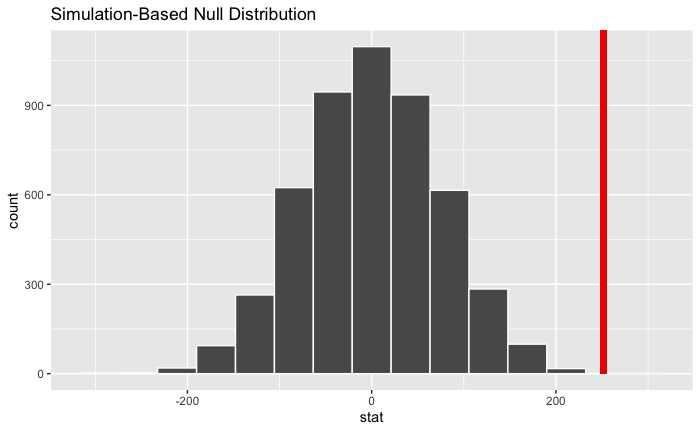

```r
null_distribution %>%
  visualise() +
  shade_p_value(obs_stat = observed_stat, direction = "right")
```

```r
options(scipen = 999)
p_value <- null_distribution %>%
  get_p_value(obs_stat = observed_stat, direction = "right")
p_value
```

| p_value |
| --- |
| 0.0002 |

## Difference in mean between paired samples.

Can you say there is a row - wise association between groups?

```r
books <- read_csv("3_two_sample_tests/data/ucla_textbooks_f18.csv")
glimpse(books)
```

```
Rows: 201
Columns: 20
$ year             <dbl> 2018, 2018, 2018, 2018, 2018, 2018, 2018, 2018, 2018, 2018, 2018…
$ term             <chr> "Fall", "Fall", "Fall", "Fall", "Fall", "Fall", "Fall", "Fall", …
$ subject          <chr> "American Indian Studies", "Anthropology", "Art", "Arts and Arch…
$ subject_abbr     <chr> "AM IND", "ANTHRO", NA, "ART&ARC", NA, "ASTR", "BMD RES", "CHEM"…
$ course           <chr> "Introduction to American Indian Studies", "Archaeology: Introdu…
$ course_num       <chr> "M10", "2", "11D", "10", "M60W", "4", "5HA", "14A", "14B", "M5A"…
$ course_numeric   <dbl> 10, 2, 11, 10, 60, 4, 5, 14, 14, 5, 10, 1, 2, 9, 10, 12, 67, 11,…
$ seminar          <lgl> FALSE, FALSE, FALSE, FALSE, FALSE, FALSE, FALSE, FALSE, FALSE, F…
$ ind_study        <lgl> FALSE, FALSE, FALSE, FALSE, FALSE, FALSE, FALSE, FALSE, FALSE, F…
$ apprenticeship   <lgl> FALSE, FALSE, FALSE, FALSE, FALSE, FALSE, FALSE, FALSE, FALSE, F…
$ internship       <lgl> FALSE, FALSE, FALSE, FALSE, FALSE, FALSE, FALSE, FALSE, FALSE, F…
$ honors_contracts <lgl> FALSE, FALSE, FALSE, FALSE, FALSE, FALSE, FALSE, FALSE, FALSE, F…
$ laboratory       <lgl> FALSE, FALSE, FALSE, FALSE, FALSE, FALSE, FALSE, FALSE, FALSE, F…
$ special_topic    <lgl> FALSE, FALSE, FALSE, FALSE, FALSE, FALSE, FALSE, FALSE, FALSE, F…
$ textbook_isbn    <dbl> 9.781138e+12, 9.780308e+12, NA, 9.780980e+12, 9.780200e+12, 9.78…
$ bookstore_new    <dbl> 47.97, 14.26, NA, 13.50, 49.26, 119.97, NA, 188.10, 215.75, NA, …
$ bookstore_used   <dbl> 44.97, 10.96, NA, 11.00, 43.26, 67.00, NA, 149.00, 162.00, NA, 1…
$ amazon_new       <dbl> 47.45, 13.55, NA, 12.53, 54.95, 124.80, NA, NA, NA, NA, 11.77, N…
$ amazon_used      <dbl> 51.20, 7.10, NA, NA, 24.83, 47.75, NA, NA, 90.00, NA, 5.41, NA, …
$ notes            <chr> NA, NA, NA, NA, NA, NA, NA, NA, "New version only from resellers…
```

alpha = 0.05 H0: mu_diff = 0 Ha: mu_fiff != 0

```r
books_diff <- books %>%
  mutate(diff_new = bookstore_new - amazon_new) %>%
  filter(!is.na(diff_new))
```

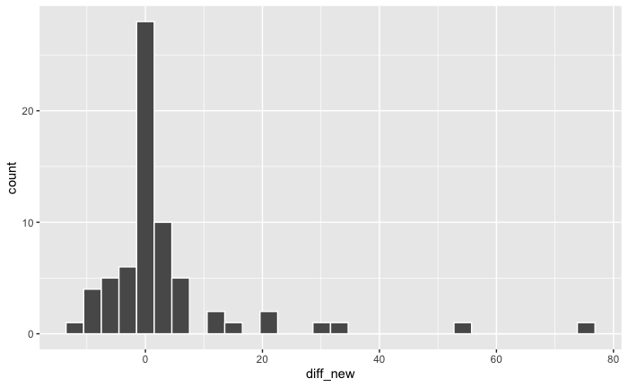

```r
books_diff %>%
  ggplot(aes(x = diff_new)) +
  geom_histogram(col = "white")
```

[output not shown]

[figure not shown]

```r
null_distribution %>%
  visualise() +
  shade_p_value(obs_stat = observed_stat, direction = "both")
```

[output not shown]

# Difference in proportions.

We would like to test whether the proportion of Obama voters who were women and the proportion of Romney voters who were women is significantly different (at a significance level alpha=0.05).

H0: women for Obama - women for Romney = 0 Ha: women for Obama - women for Romney != 0

```r
glimpse(poll)
```

```
Rows: 2,551
Columns: 2
$ vote   <chr> "obama", "obama", "obama", "obama", "obama", "obama", "obama", "obama", "o…
$ gender <chr> "woman", "woman", "woman", "woman", "woman", "woman", "woman", "woman", "w…
```

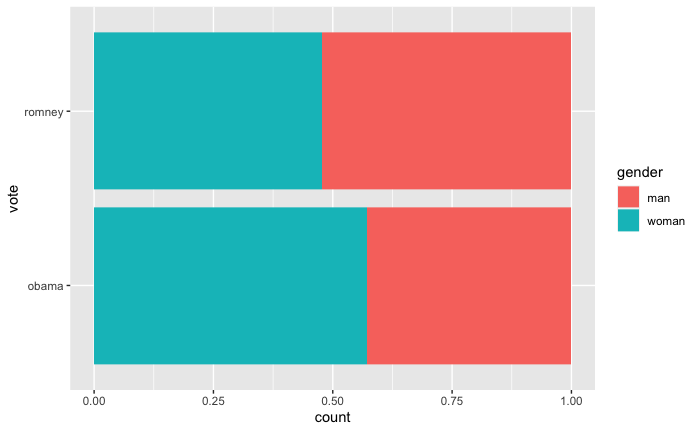

```r
ggplot(poll, aes(x = vote, fill = gender)) +
  geom_bar(position = "fill") +
  coord_flip()
```

```r
poll_observed_stat <- poll %>%
  specify(gender ~ vote, success = "woman") %>%
  calculate(stat = "diff in props", order = c("obama", "romney"))
poll_observed_stat
```

| stat |
| --- |
| 0.09481102 |

```r
poll_null_distribution <- poll %>%
  specify(gender ~ vote, success = "woman") %>%
  hypothesise(null = "independence") %>%
  generate(reps = 5000, type = "permute") %>%
  calculate(stat = "diff in props", order = c("obama", "romney"))
poll_null_distribution
```

| replicate | stat |
| --- | --- |
| 1 | 0.0179315189 |
| 2 | -0.0008961147 |
| 3 | 0.0242073967 |
| 4 | -0.0087409620 |
| 5 | 0.0273453357 |
| 6 | -0.0071719925 |
| 7 | -0.0071719925 |
| 8 | -0.0008961147 |
| 9 | 0.0022418243 |
| 10 | 0.0147935800 |

[output cut: 990 more lines]

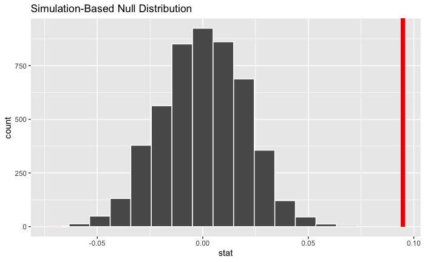

```r
poll_null_distribution %>%
  visualise() +
  shade_p_value(obs_stat = poll_observed_stat, direction = "both")
```

[output not shown]

# Task:

Calculate the 95% CI for the point estimate of the difference in the two proportions.

[output not shown]

[output cut: 990 more lines]

```r
bootstrap_prop_ci <- bootstrap_distribution %>%
  get_ci(level = 0.95, type = "percentile")
bootstrap_prop_ci
```

| lower_ci | upper_ci |
| --- | --- |
| 0.05709346 | 0.1341162 |

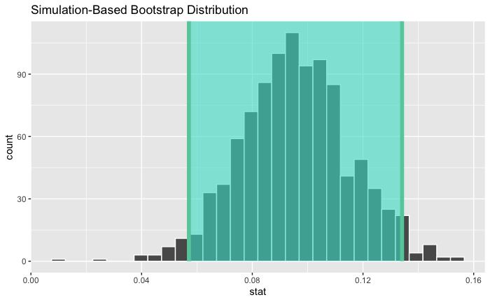

```r
bootstrap_distribution %>%
  visualise(bins = 30) +
  shade_ci(endpoints = bootstrap_prop_ci)
```